# Question

It can be helpful to represent an ellipse in parametric form:

$$\begin{align}
x &= h+r_1 \cos(t)\\
y &= k+r_2 \sin(t)
\end{align}$$

where the center is $(h,k)$, the horizontal radius is $r_1$, and the vertical radius is $r_2$.

Determine the parameters of the ellipse in the graph below. You can assume all parameters are integers.

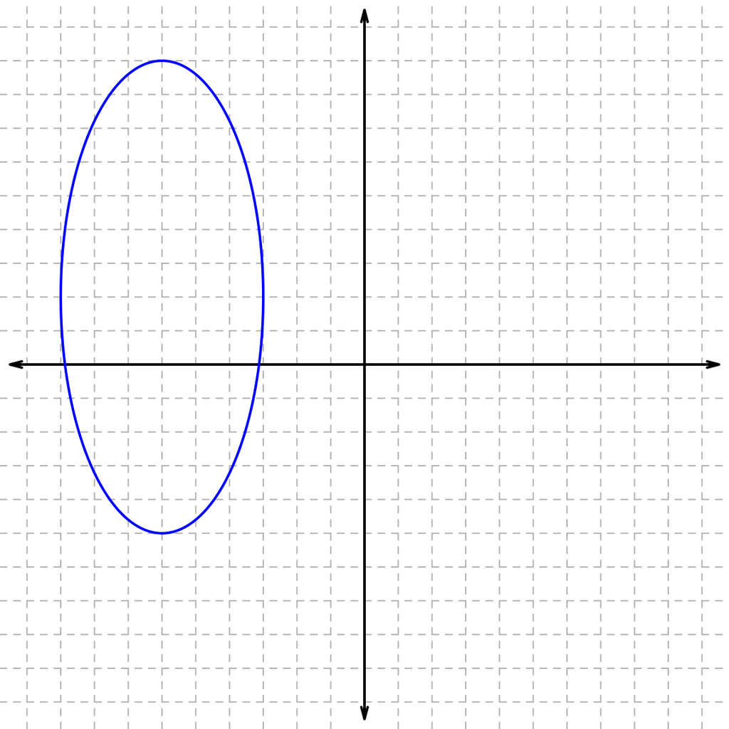

- $h=$ ##ANSWER1##
- $k=$ ##ANSWER2##
- $r_1=$ ##ANSWER3##
- $r_2=$ ##ANSWER4##

Which of the following parametric systems, for $0\le t<2\pi$, would give the graph above?

A:

$$x=-2+3\cos(t)$$
$$y=-6+7\sin(t)$$

B:

$$x=-2+3\cos(t)$$
$$y=6+7\sin(t)$$

C:

$$x=2+3\cos(t)$$
$$y=-6+7\sin(t)$$

D:

$$x=2+3\cos(t)$$
$$y=6+7\sin(t)$$

E:

$$x=-6+3\cos(t)$$
$$y=-2+7\sin(t)$$

F:

$$x=-6+3\cos(t)$$
$$y=2+7\sin(t)$$

G:

$$x=6+3\cos(t)$$
$$y=-2+7\sin(t)$$

H:

$$x=6+3\cos(t)$$
$$y=2+7\sin(t)$$

I:

$$x=-2+7\cos(t)$$
$$y=-6+3\sin(t)$$

J:

$$x=-2+7\cos(t)$$
$$y=6+3\sin(t)$$

K:

$$x=2+7\cos(t)$$
$$y=-6+3\sin(t)$$

L:

$$x=2+7\cos(t)$$
$$y=6+3\sin(t)$$

M:

$$x=-6+7\cos(t)$$
$$y=-2+3\sin(t)$$

N:

$$x=-6+7\cos(t)$$
$$y=2+3\sin(t)$$

O:

$$x=6+7\cos(t)$$
$$y=-2+3\sin(t)$$

P:

$$x=6+7\cos(t)$$
$$y=2+3\sin(t)$$

Parametric system ##ANSWER5##

## Answerlist

- -10
- -9
- -8
- -7
- -6
- -5
- -4
- -3
- -2
- -1
- 0
- 1
- 2
- 3
- 4
- 5
- 6
- 7
- 8
- 9
- 10
- -10
- -9
- -8
- -7
- -6
- -5
- -4
- -3
- -2
- -1
- 0
- 1
- 2
- 3
- 4
- 5
- 6
- 7
- 8
- 9
- 10
- 1
- 2
- 3
- 4
- 5
- 6
- 7
- 8
- 9
- 10
- 1
- 2
- 3
- 4
- 5
- 6
- 7
- 8
- 9
- 10
- A
- B
- C
- D
- E
- F
- G
- H
- I
- J
- K
- L
- M
- N
- O
- P

# Solution

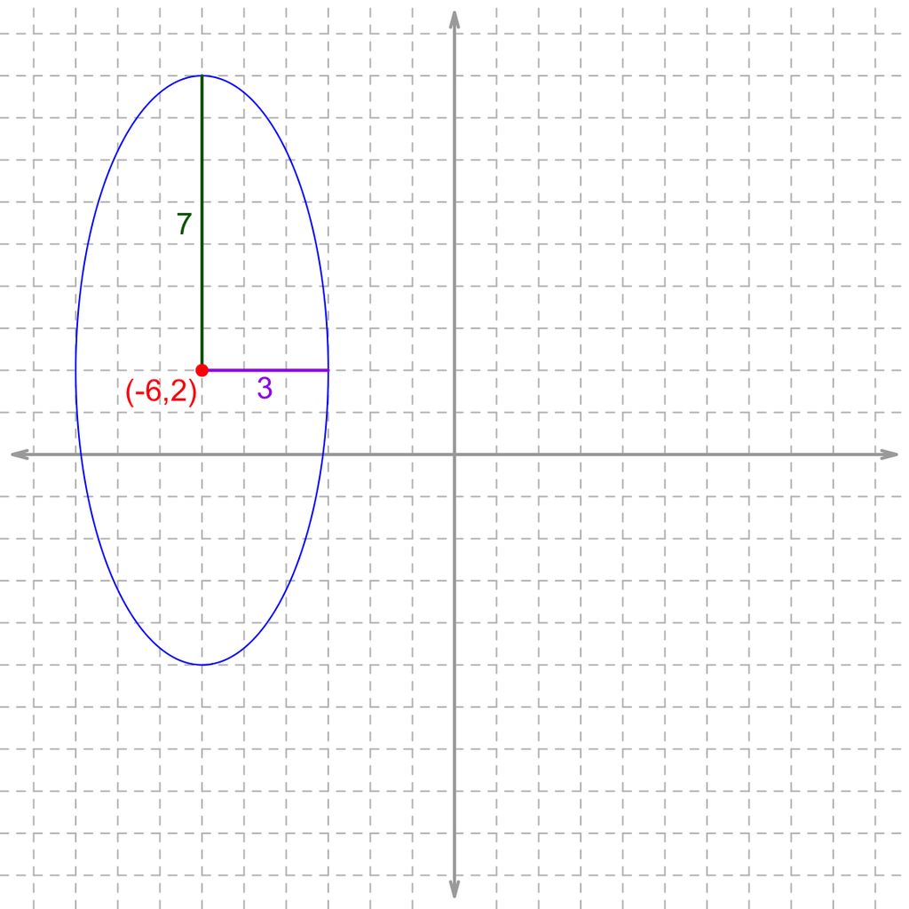

So:
$$\begin{align}
h &= -6\\\\
k &= 2\\\\
r_1 &= 3\\\\
r_2 &= 7
\end{align}$$

Substitute those numbers into the parametric system:

$$x=-6+3\cos(t)$$
$$y=2+7\sin(t)$$

In [Desmos](https://www.desmos.com/calculator), you’d graph this by typing:

$$(-6+3\cos(t),~2+7\sin(t))$$

and setting bounding $t$ so that $0\le t< 2\pi$.

# Meta-information

extype: cloze exclozetype: schoice|schoice|schoice|schoice|schoice exsolution: 000010000000000000000|000000000000100000000|0010000000|0000001000|0000010000000000 exname: ellipse_get_pams